# IODS course project

## Dataset

Begin by loading the analysis data. Let’s use the “official” csv-file; an R script to produce the wrangled data is in the [repo](https://github.com/kuuravar/IODS-project).

```r
rm(list=ls())

# read in the data, convert strings to factors
human <- read.csv("http://s3.amazonaws.com/assets.datacamp.com/production/course_2218/datasets/human2.txt",
                  header = TRUE, sep = ",", stringsAsFactors = TRUE)

dim(human)
```

```
## [1] 155   8
```

```r
summary(human)
```

```
##     Edu2.FM          Labo.FM          Edu.Exp         Life.Exp
##  Min.   :0.1717   Min.   :0.1857   Min.   : 5.40   Min.   :49.00
##  1st Qu.:0.7264   1st Qu.:0.5984   1st Qu.:11.25   1st Qu.:66.30
##  Median :0.9375   Median :0.7535   Median :13.50   Median :74.20
##  Mean   :0.8529   Mean   :0.7074   Mean   :13.18   Mean   :71.65
##  3rd Qu.:0.9968   3rd Qu.:0.8535   3rd Qu.:15.20   3rd Qu.:77.25
##  Max.   :1.4967   Max.   :1.0380   Max.   :20.20   Max.   :83.50
##       GNI            Mat.Mor         Ado.Birth         Parli.F
##  Min.   :   581   Min.   :   1.0   Min.   :  0.60   Min.   : 0.00
##  1st Qu.:  4198   1st Qu.:  11.5   1st Qu.: 12.65   1st Qu.:12.40
##  Median : 12040   Median :  49.0   Median : 33.60   Median :19.30
##  Mean   : 17628   Mean   : 149.1   Mean   : 47.16   Mean   :20.91
##  3rd Qu.: 24512   3rd Qu.: 190.0   3rd Qu.: 71.95   3rd Qu.:27.95
##  Max.   :123124   Max.   :1100.0   Max.   :204.80   Max.   :57.50
```

`Life.Exp` spans the range [49, 83.50], `GNI` [581, 123124], maternal mortality ratio (per 100000) [1.0, 1100] and adolescent birth rate (per 100000) [0.60, 204.80].

Plot the scatterplot and correlations between the variables.

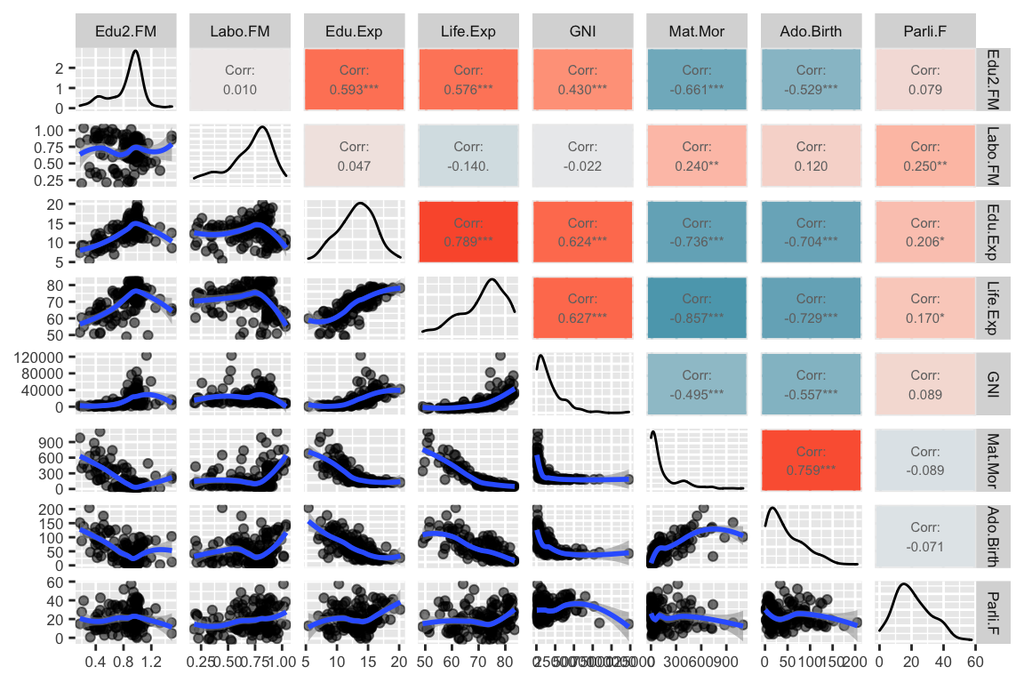

```r
library(GGally)
library(ggplot2)

lower <- function(data, mapping, method="loess", ...){
      p <- ggplot(data = data, mapping = mapping) +
      geom_point() +
      geom_smooth(method=method, ...)
      p
}

p <- ggpairs(human, mapping = aes(alpha = 0.3),
             lower = list(continuous = lower),
             upper = list(continuous = wrap("cor", size = 2))) +
      theme(text = element_text(size = 8))

# Add color to correlations
# stackoverflow.com/questions/45873483/

# correlations matrix plot
p.corr <- ggcorr(human, label = TRUE, label_round = 3,
                 palette = "RdBu")

# get colors
g2 <- ggplotGrob(p.corr)
colors <- g2$grobs[[6]]$children[[3]]$gp$fill

# Change background color to tiles in the upper triangular matrix of plots
idx <- 1
for (k1 in 1:(ncol(human) - 1)) {
  for (k2 in (k1 + 1):ncol(human)) {
    plt <- getPlot(p, k1, k2) +
     theme(panel.background = element_rect(fill = colors[idx], color="white"),
           panel.grid.major = element_line(color = colors[idx]))
    p <- putPlot(p, plt, k1, k2)
    idx <- idx + 1
  }
}

p
```

There are many significant strong correlations. Eg. `Life.Exp` correlates positively with `Edu.Exp`, and `Mat.Mor` correlates positively with `Ado.Birth`. `Life.Exp`, `Edu.Exp` correlate negatively with `Mat.Mor`. `Life.Exp` and `Ado.Birth` correlate negatively as well.

Let’s examine the correlations with corrplot also to see better the groups of positive and negative correlations. Only `Labo.FM` and `Parli.F` do not correlate strongly with anything.

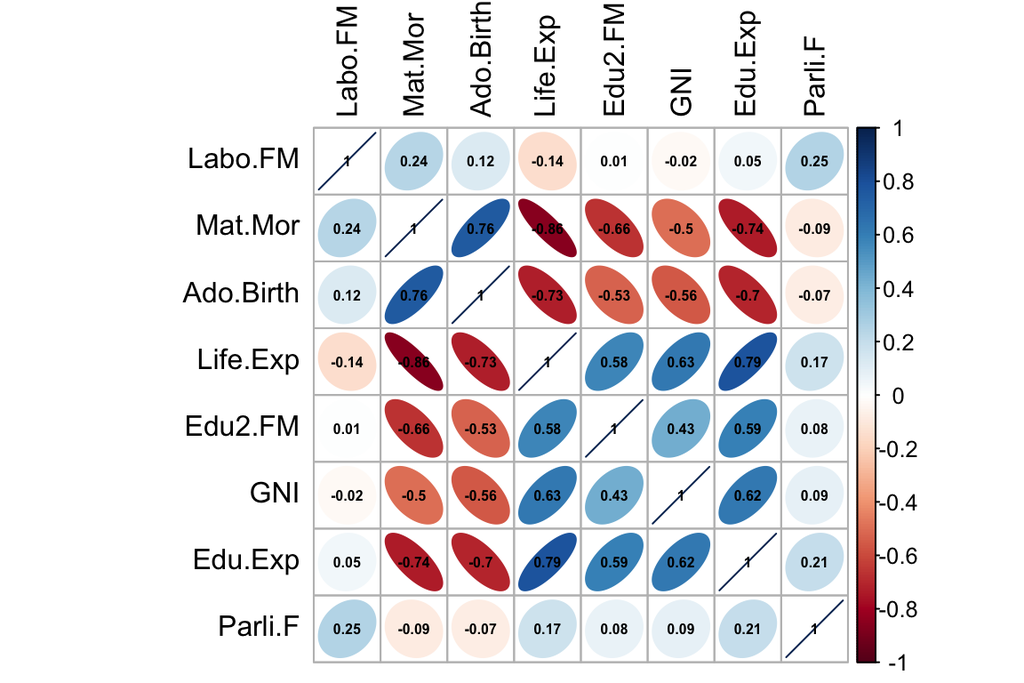

```r
library(corrplot)

cor.matrix <- cor(human)

rownames(cor.matrix) <- colnames(cor.matrix)

corrplot(as.matrix(cor.matrix), method = "ellipse",
         order = "AOE", number.cex = 0.5,  # Use some nice ordering
         tl.cex = 1, tl.col = "black", addCoef.col = 'black')
```

Then plot histograms to assess the distributions.

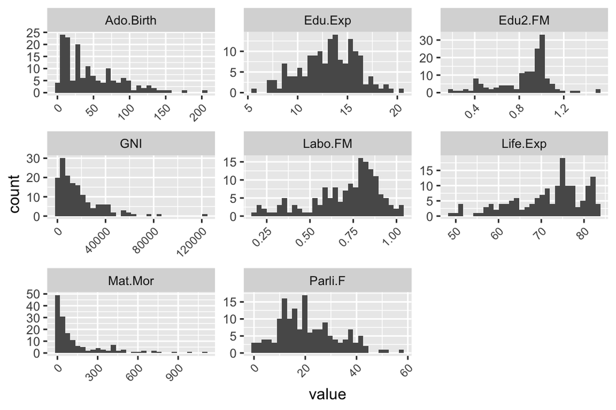

```r
library(tidyverse)

gather(human) %>% ggplot(aes(value)) +
  facet_wrap("key", scales = "free") +
  geom_histogram() + theme(axis.text.x = element_text(angle = 45, hjust = 1, size = 8))
```

`Edu.Exp` is close to normal distribution (passes Shapiro-Wilk normality test). `GNI`, `Mat.Mor` and `Ado.Birth` are right skewed, `Life.Exp` is left skewed.

## PCA

Perform PCA on non-standardized data first (follow code from course’s DataCamp)

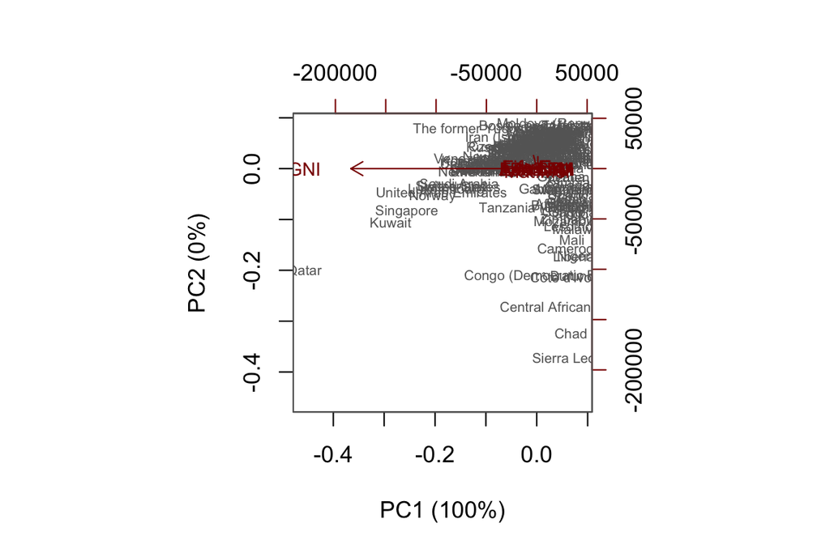

Figure 1. PCA on non-standardized data. GNI’s absolute variance is very large and it ends up explaining nearly all the absolute variance.

```r
human.pca <- prcomp(human)  # SVD

s <- summary(human.pca)

# rounded percentages of variance captured by each PC
pca.pr <- round(100 * s$importance[2,], digits = 1)

# create object pc_lab to be used as axis labels
pc.lab <- paste0(names(pca.pr), " (", pca.pr, "%)")

# draw a biplot
biplot(human.pca, cex = c(0.6, 0.8), col = c("grey40", "darkred"),
       xlab = pc.lab[1], ylab = pc.lab[2])
```

Well, since the data is not standardized, GNI appears to capture virtually all variability in the data as it has the highest absolute variance by far. Qatar stands out along the first PC and is opposite of e.g. Chad in GNI.

```r
sort(sapply(human, var))
```

```
##      Labo.FM      Edu2.FM      Edu.Exp     Life.Exp      Parli.F    Ado.Birth
## 3.951293e-02 5.838970e-02 8.067024e+00 6.942328e+01 1.319683e+02 1.690201e+03
##      Mat.Mor          GNI
## 4.485483e+04 3.438745e+08
```

Let’s standardize and replot.

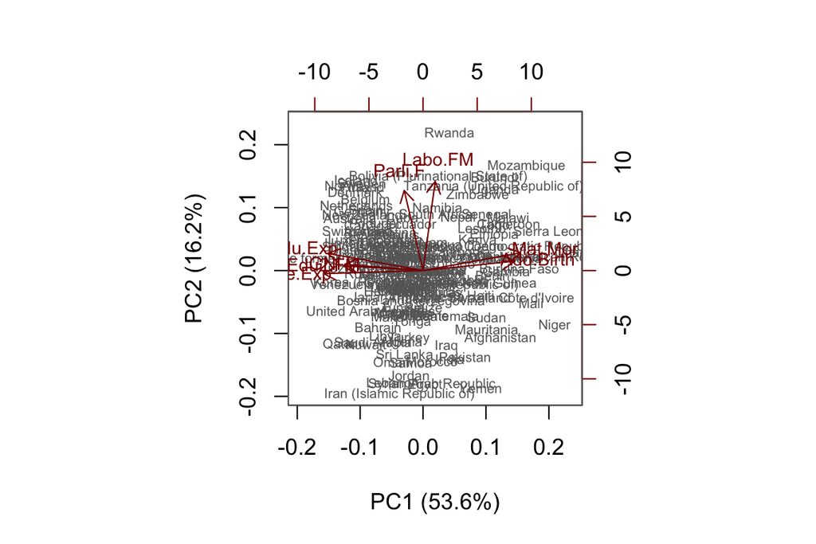

Figure 2. PCA on standardized data. Life expectancy, expected years of schooling and ratio of female to male populations with secondary education correlate with the first principal component and are of approximately same magnitude. They have an opposite effect to adolescent birth rate and maternal mortality. Ratio of labour force participation of females to males and percent of parliament representation for females are orthogonal to other variables and correlate with the second principal component.

```r
human.pca <- prcomp(human, scale = TRUE)

s <- summary(human.pca)

# rounded percentages of variance captured by each PC
pca.pr <- round(100 * s$importance[2,], digits = 1)

# create object pc_lab to be used as axis labels
pc.lab <- paste0(names(pca.pr), " (", pca.pr, "%)")

# draw a biplot
biplot(human.pca, cex = c(0.6, 0.8), col = c("grey40", "darkred"),
       xlab = pc.lab[1], ylab = pc.lab[2])
```

Now the two first principal components explain 69.8% of variation in the data, mainly due to PC1 (53.6%). `Life.Exp`, `Edu.Exp` and `Edu2.FM` all point along PC1 in the same direction, `Mot.Mor` and `Ado.Birth` point in the opposite direction, which is coherent with the correlation analysis. `Parli.F` and `Labo.FM` correlate with each other and PC2; as we calculated before, correlation is not very strong.

Third principal component explains around 9.6% of the variance and the following components less. 8 principal components are needed to fully explain the variance of the data.

```r
summary(human.pca)
```

```
## Importance of components:
##                           PC1    PC2     PC3     PC4     PC5     PC6     PC7
## Standard deviation     2.0708 1.1397 0.87505 0.77886 0.66196 0.53631 0.45900
## Proportion of Variance 0.5361 0.1624 0.09571 0.07583 0.05477 0.03595 0.02634
## Cumulative Proportion  0.5361 0.6984 0.79413 0.86996 0.92473 0.96069 0.98702
##                            PC8
## Standard deviation     0.32224
## Proportion of Variance 0.01298
## Cumulative Proportion  1.00000
```

## PCA interpretation

Based on the deductions above, we can conclude that PC1 mostly captures the variance in `Life.Exp`, `Edu.Exp` and `Edu2.FM`, as well as `Mot.Mor` and `Ado.Birth`. It explains 53.6% of the total variance in the standardized `human` data. `Mot.Mor` and `Ado.Birth` point very intuitively in the opposite direction to education, education ratio of females to males, and to life expectancy.

PC2 captures variance in `Parli.F` and `Labo.FM`, explaining 16.2% of the total variance in the data. These variables exhibit their effects in the same direction along PC2. Thus female parliament and labor representation are suggested to have similar effects.

All in all, the first two PCs are enough to approximately represent the data as the total variance explained is relatively good, 69.8%.

## Tea dataset

Load the tea dataset

```r
library(FactoMineR)

data(tea)

str(tea)
```

```
## 'data.frame':    300 obs. of  36 variables:
##  $ breakfast       : Factor w/ 2 levels "breakfast","Not.breakfast": 1 1 2 2 1 2 1 2 1 1 ...
##  $ tea.time        : Factor w/ 2 levels "Not.tea time",..: 1 1 2 1 1 1 2 2 2 1 ...
##  $ evening         : Factor w/ 2 levels "evening","Not.evening": 2 2 1 2 1 2 2 1 2 1 ...
##  $ lunch           : Factor w/ 2 levels "lunch","Not.lunch": 2 2 2 2 2 2 2 2 2 2 ...
##  $ dinner          : Factor w/ 2 levels "dinner","Not.dinner": 2 2 1 1 2 1 2 2 2 2 ...
##  $ always          : Factor w/ 2 levels "always","Not.always": 2 2 2 2 1 2 2 2 2 2 ...
##  $ home            : Factor w/ 2 levels "home","Not.home": 1 1 1 1 1 1 1 1 1 1 ...
##  $ work            : Factor w/ 2 levels "Not.work","work": 1 1 2 1 1 1 1 1 1 1 ...
##  $ tearoom         : Factor w/ 2 levels "Not.tearoom",..: 1 1 1 1 1 1 1 1 1 2 ...
##  $ friends         : Factor w/ 2 levels "friends","Not.friends": 2 2 1 2 2 2 1 2 2 2 ...
##  $ resto           : Factor w/ 2 levels "Not.resto","resto": 1 1 2 1 1 1 1 1 1 1 ...
##  $ pub             : Factor w/ 2 levels "Not.pub","pub": 1 1 1 1 1 1 1 1 1 1 ...
##  $ Tea             : Factor w/ 3 levels "black","Earl Grey",..: 1 1 2 2 2 2 2 1 2 1 ...
##  $ How             : Factor w/ 4 levels "alone","lemon",..: 1 3 1 1 1 1 1 3 3 1 ...
```

[output cut: 22 more lines]

```r
dim(tea)
```

```
## [1] 300  36
```

```r
table(sapply(tea, typeof))
```

```
##
## integer
##      36
```

The FactoMineR tea data has 300 rows and 36 columns, all of them except for `age` are factors encoded into integers. It is questionnaire data, from [documentation](https://cran.r-project.org/web/packages/FactoMineR/FactoMineR.pdf):

“We asked to 300 individuals how they drink tea (18 questions), what are their product’s perception (12 questions) and some personal details (4 questions).”

### Visualize the data

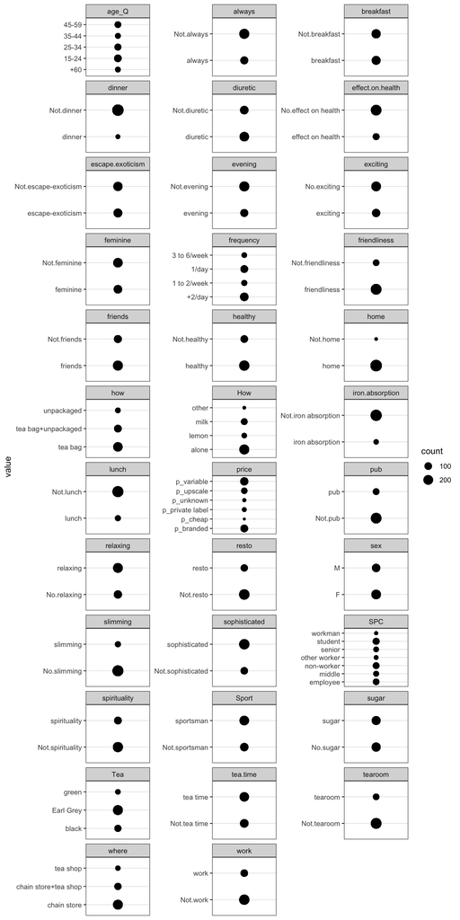

```r
# tea %>% select(-age) %>%
tea.cat <- tea %>% select(-age)

p <-
  tea %>%
    select(-age) %>%
    gather %>%
    group_by(value) %>%
    mutate(count = n()) %>%
    ggplot(aes(value)) + geom_point(y = .5, aes(size = count)) +
      facet_wrap("key", scales = "free", strip.position = "top", ncol = 3) +
      # facet_grid("key", scales = "free", space = "free") +
      theme(axis.text.x = element_text(angle = 45, vjust = 0.5, hjust=1),
            panel.spacing = unit(2, "lines")) +
      coord_flip() +
      theme_bw()

# https://stackoverflow.com/questions/52341385/
p
```

Plot age separately

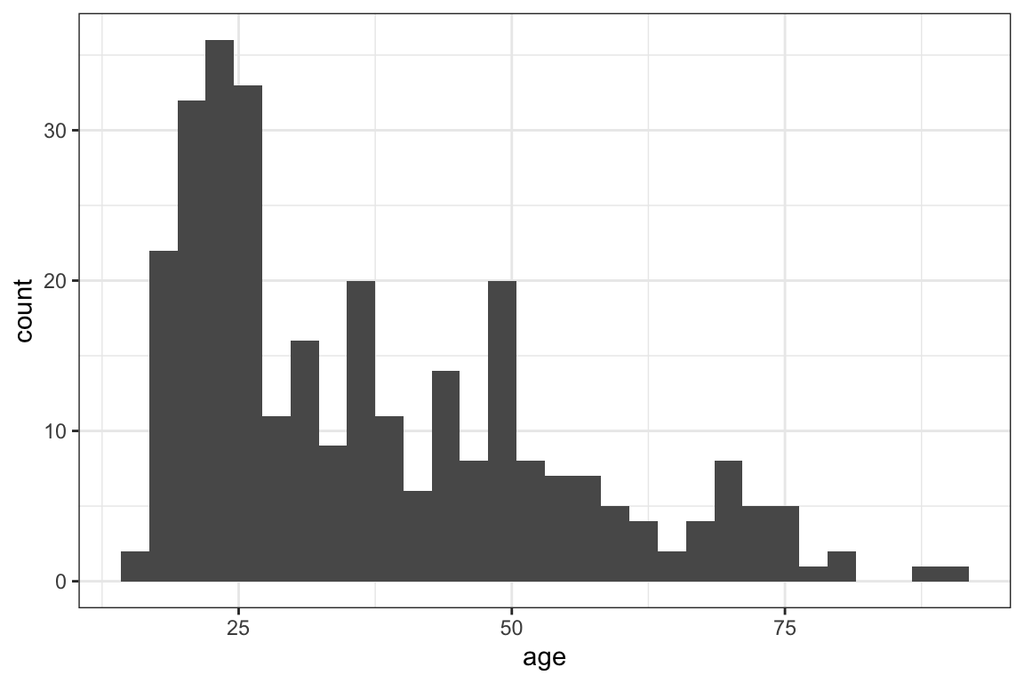

```r
ggplot(tea, aes(age)) + geom_histogram() + theme_bw()
```

### MCA

Perform multiple correspondence analysis (with indicator matrix) on the FactoMineR tea data.

```r
mca <- MCA(tea %>% select(-age), graph = FALSE)
summary(mca)
```

```
##
## Call:
## MCA(X = tea %>% select(-age), graph = FALSE)
##
##
## Eigenvalues
##                        Dim.1   Dim.2   Dim.3   Dim.4   Dim.5   Dim.6   Dim.7
## Variance               0.090   0.082   0.070   0.063   0.056   0.053   0.050
## % of var.              5.838   5.292   4.551   4.057   3.616   3.465   3.272
## Cumulative % of var.   5.838  11.130  15.681  19.738  23.354  26.819  30.091
##                        Dim.8   Dim.9  Dim.10  Dim.11  Dim.12  Dim.13  Dim.14
## Variance               0.048   0.047   0.044   0.041   0.040   0.039   0.037
## % of var.              3.090   3.053   2.834   2.643   2.623   2.531   2.388
## Cumulative % of var.  33.181  36.234  39.068  41.711  44.334  46.865  49.252
##                       Dim.15  Dim.16  Dim.17  Dim.18  Dim.19  Dim.20  Dim.21
## Variance               0.036   0.035   0.034   0.032   0.031   0.031   0.030
## % of var.              2.302   2.275   2.172   2.085   2.013   2.011   1.915
## Cumulative % of var.  51.554  53.829  56.000  58.086  60.099  62.110  64.025
##                       Dim.22  Dim.23  Dim.24  Dim.25  Dim.26  Dim.27  Dim.28
## Variance               0.028   0.027   0.026   0.025   0.025   0.024   0.024
## % of var.              1.847   1.740   1.686   1.638   1.609   1.571   1.524
## Cumulative % of var.  65.872  67.611  69.297  70.935  72.544  74.115  75.639
##                       Dim.29  Dim.30  Dim.31  Dim.32  Dim.33  Dim.34  Dim.35
## Variance               0.023   0.022   0.021   0.020   0.020   0.019   0.019
## % of var.              1.459   1.425   1.378   1.322   1.281   1.241   1.222
## Cumulative % of var.  77.099  78.523  79.901  81.223  82.504  83.745  84.967
##                       Dim.36  Dim.37  Dim.38  Dim.39  Dim.40  Dim.41  Dim.42
## Variance               0.018   0.017   0.017   0.016   0.015   0.015   0.014
## % of var.              1.152   1.092   1.072   1.019   0.993   0.950   0.924
## Cumulative % of var.  86.119  87.211  88.283  89.301  90.294  91.244  92.169
##                       Dim.43  Dim.44  Dim.45  Dim.46  Dim.47  Dim.48  Dim.49
## Variance               0.014   0.013   0.012   0.011   0.011   0.010   0.010
## % of var.              0.891   0.833   0.792   0.729   0.716   0.666   0.660
## Cumulative % of var.  93.060  93.893  94.684  95.414  96.130  96.796  97.456
##                       Dim.50  Dim.51  Dim.52  Dim.53  Dim.54
## Variance               0.009   0.009   0.008   0.007   0.006
## % of var.              0.605   0.584   0.519   0.447   0.390
## Cumulative % of var.  98.060  98.644  99.163  99.610 100.000
##
## Individuals (the 10 first)
```

[output cut: 44 more lines]

```
## dinner         0.796  1.805  0.048  3.777 |
## Not.dinner    -0.060  0.136  0.048 -3.777 |
##
## Categorical variables (eta2)
##                 Dim.1 Dim.2 Dim.3
## breakfast     | 0.031 0.000 0.011 |
## tea.time      | 0.240 0.000 0.003 |
## evening       | 0.040 0.087 0.062 |
## lunch         | 0.062 0.029 0.010 |
## dinner        | 0.092 0.000 0.048 |
## always        | 0.056 0.035 0.007 |
## home          | 0.016 0.002 0.030 |
## work          | 0.075 0.020 0.022 |
## tearoom       | 0.321 0.019 0.031 |
## friends       | 0.186 0.061 0.030 |
```

Eigenvalue output contains the variances and the respective percentage of variance explained by each dimension.

Individuals output shows the coordinates, contribution of the individual as percent, and the squared cosine which measures the degree of association between variable categories and a dimension [`[`1`]`](http://www.sthda.com/english/articles/31-principal-component-methods-in-r-practical-guide/114-mca-multiple-correspondence-analysis-in-r-essentials/).

Categories are detailed similarly to individuals. The v.test measures if the category is significantly different from zero along a dimension (is abs(v.test) > 2, sign gives direction along the dimension). Categorical variables section shows squared correlation ratio to the dimensions.

Before going into interpretation, let’s - for pedagogical reasons - follow the [example](https://www.youtube.com/watch?v=reG8Y9ZgcaQ) of a FactoMineR developer and redo the MCA with age as a quantitative supplementary variable and a set of others as qualitative supplementary variables.

```r
mca <- MCA(tea, quanti.sup = 19, quali.sup = 20:36, graph = FALSE)  # 19 = "age"
summary(mca)
```

```
##
## Call:
## MCA(X = tea, quanti.sup = 19, quali.sup = 20:36, graph = FALSE)
##
##
## Eigenvalues
##                        Dim.1   Dim.2   Dim.3   Dim.4   Dim.5   Dim.6   Dim.7
## Variance               0.148   0.122   0.090   0.078   0.074   0.071   0.068
## % of var.              9.885   8.103   6.001   5.204   4.917   4.759   4.522
## Cumulative % of var.   9.885  17.988  23.989  29.192  34.109  38.868  43.390
##                        Dim.8   Dim.9  Dim.10  Dim.11  Dim.12  Dim.13  Dim.14
## Variance               0.065   0.062   0.059   0.057   0.054   0.052   0.049
## % of var.              4.355   4.123   3.902   3.805   3.628   3.462   3.250
## Cumulative % of var.  47.745  51.867  55.769  59.574  63.202  66.664  69.914
##                       Dim.15  Dim.16  Dim.17  Dim.18  Dim.19  Dim.20  Dim.21
## Variance               0.048   0.047   0.046   0.040   0.038   0.037   0.036
## % of var.              3.221   3.127   3.037   2.683   2.541   2.438   2.378
## Cumulative % of var.  73.135  76.262  79.298  81.982  84.523  86.961  89.339
##                       Dim.22  Dim.23  Dim.24  Dim.25  Dim.26  Dim.27
## Variance               0.035   0.031   0.029   0.027   0.021   0.017
## % of var.              2.323   2.055   1.915   1.821   1.407   1.139
## Cumulative % of var.  91.662  93.717  95.633  97.454  98.861 100.000
##
## Individuals (the 10 first)
##                  Dim.1    ctr   cos2    Dim.2    ctr   cos2    Dim.3    ctr
## 1             | -0.541  0.658  0.143 | -0.149  0.061  0.011 | -0.306  0.347
## 2             | -0.361  0.293  0.133 | -0.078  0.017  0.006 | -0.633  1.483
## 3             |  0.073  0.012  0.003 | -0.169  0.079  0.018 |  0.246  0.224
## 4             | -0.572  0.735  0.235 |  0.018  0.001  0.000 |  0.203  0.153
## 5             | -0.253  0.144  0.079 | -0.118  0.038  0.017 |  0.006  0.000
## 6             | -0.684  1.053  0.231 |  0.032  0.003  0.001 | -0.018  0.001
## 7             | -0.111  0.027  0.022 | -0.182  0.090  0.059 | -0.207  0.159
## 8             | -0.210  0.099  0.043 | -0.068  0.013  0.004 | -0.421  0.655
## 9             |  0.118  0.031  0.012 |  0.229  0.144  0.044 | -0.538  1.070
## 10            |  0.258  0.150  0.045 |  0.478  0.627  0.156 | -0.482  0.861
##                 cos2
## 1              0.046 |
## 2              0.409 |
## 3              0.038 |
## 4              0.030 |
```

[output cut: 69 more lines]

```
##                    Dim.1 Dim.2 Dim.3
## sex              | 0.033 0.017 0.003 |
## SPC              | 0.032 0.053 0.076 |
## Sport            | 0.001 0.000 0.002 |
## age_Q            | 0.008 0.077 0.146 |
## frequency        | 0.094 0.006 0.064 |
## escape.exoticism | 0.000 0.007 0.000 |
## spirituality     | 0.005 0.000 0.016 |
## healthy          | 0.000 0.000 0.008 |
## diuretic         | 0.004 0.000 0.013 |
## friendliness     | 0.071 0.001 0.013 |
##
## Supplementary continuous variable
##                  Dim.1    Dim.2    Dim.3
## age           |  0.042 |  0.204 | -0.340 |
```

The output of summary contains now also supplementary categories, for which there are no contributions as they are not used to build the explanatory dimensions.

Plot first the quantitative supplementary `age` variable. It seems `age` does not correlate strongly with the first two dimensions.

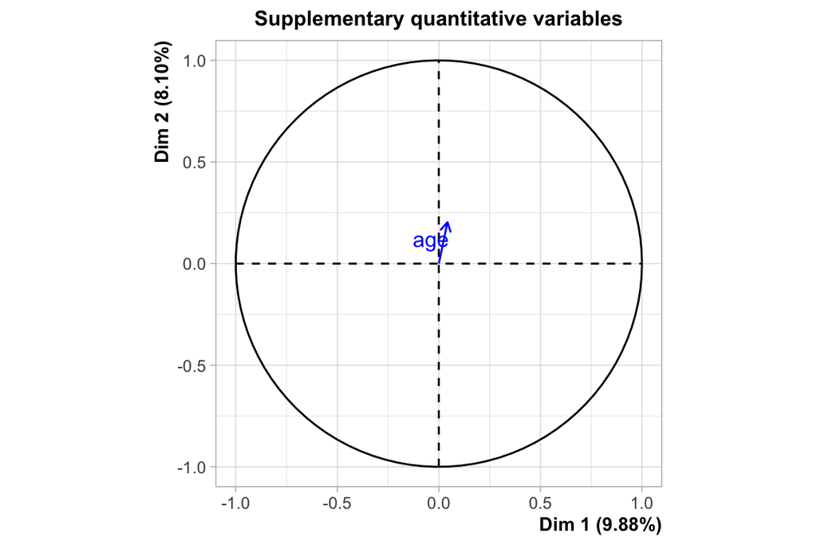

```r
plot.MCA(mca, choix = "quanti.sup")
```

Then plot variable graph for the correlation ratios. `where`, `tearoom` and `how` correlate with the first dimension more than other variables. Similarly `where`, `price` and `how` correlate with the second dimension more than the other variables. Active variables are in red, suppl. categorical variables in green, and suppl. continuous variable `age` in blue.

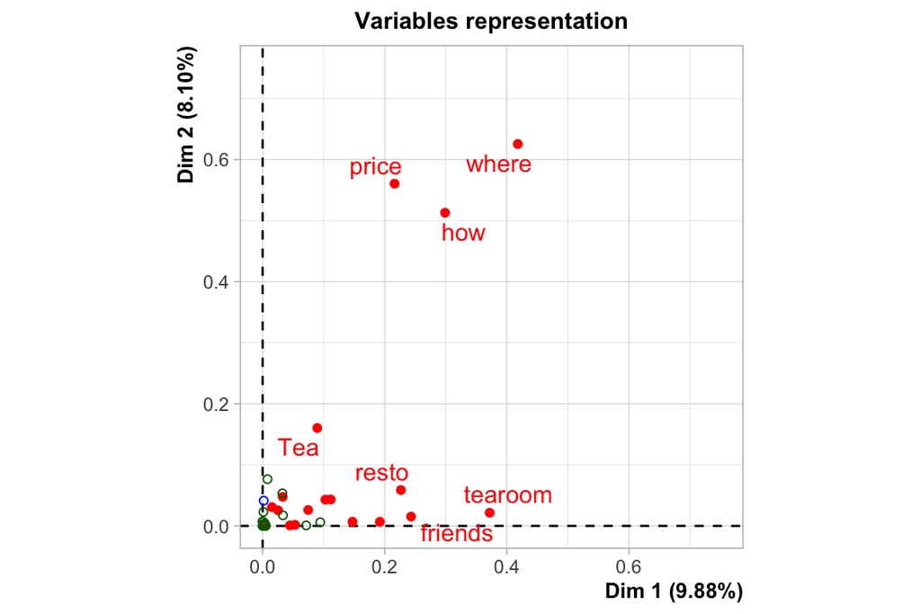

```r
plot.MCA(mca, choix = "var", xlim = c(0, 0.75), ylim = c(0, 0.75))
```

Then plot the graph for individuals and the category values. The plot is quite busy; it appears that the values `tea shop` (where), `unpackaged` (how) and `p_upscale` (price) are important for dimension 2. `other`(How [sic]) and `tearoom` (tearoom), `chain store+tea shop` (where) are important for dimension 1. Other data points are more clustered towards the middle.

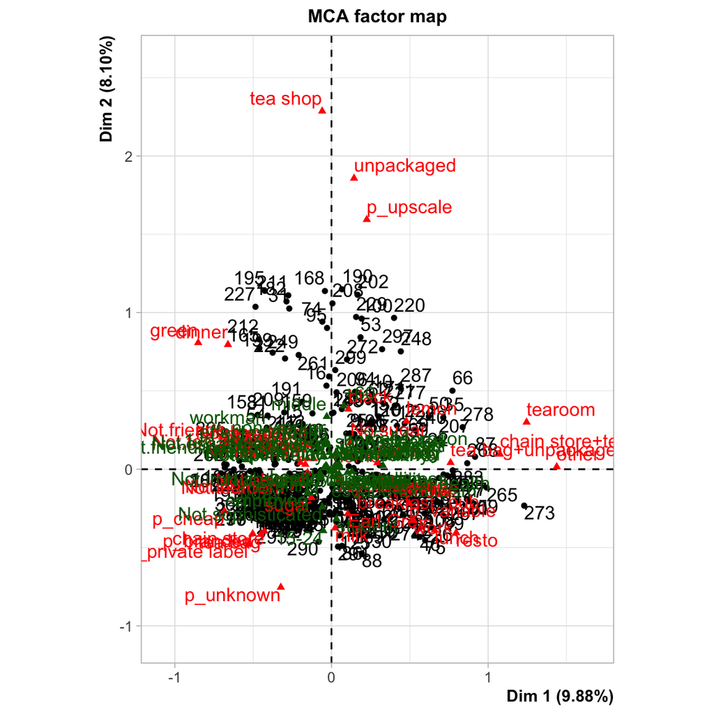

```r
plot.MCA(mca, choix = "ind")
```

For individuals, there appears to be a denser region in the third quadrant. Individuals contributing the most are on the periphery of the point cloud. It seems the individuals are separated nicely by where they get their tea from (`where`). This is not too suprising, as that variable was found to be important in the earlier plots.

Conclusions for the active categories are as before.

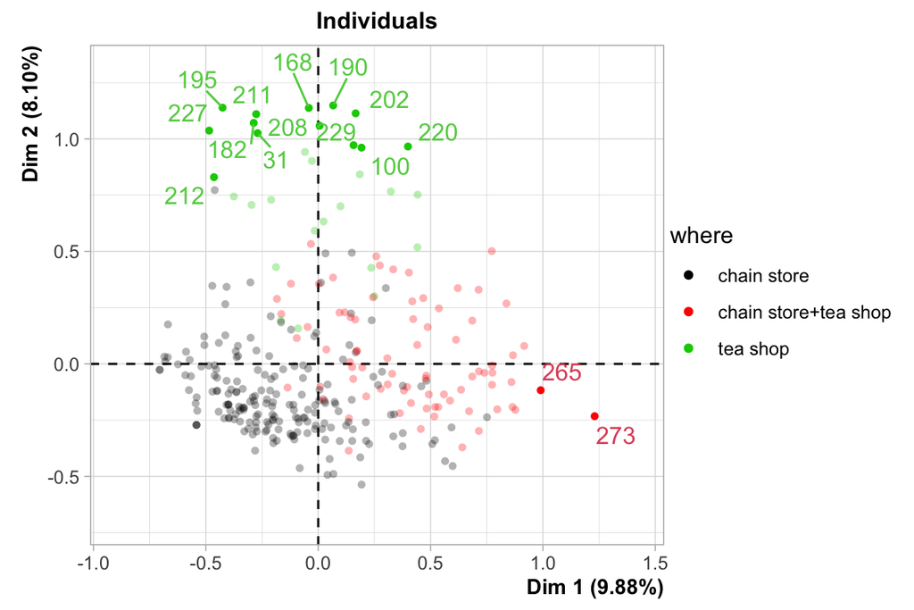

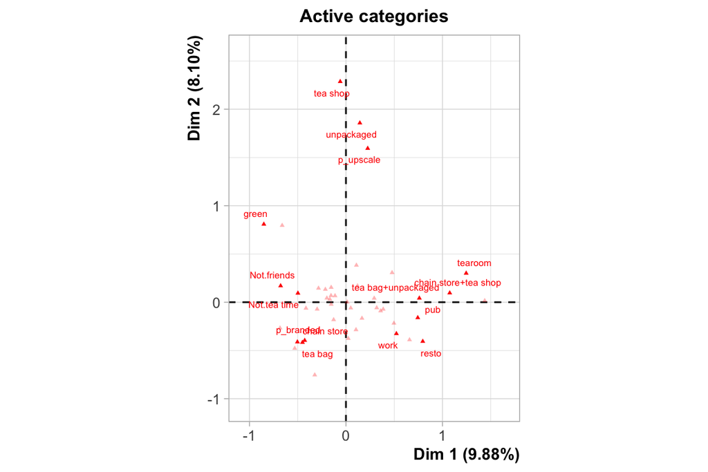

```r
op <- par(mfcol=c(1, 2),
          mar = c(4, 4, 2, 1),
          mgp = c(2, 1, 0))

plot(mca, invisible = c("var", "quali.sup", "quanti.sup"),
     title = "Individuals", select = "contrib 15", habillage = "where")
plot(mca, invisible = c("ind", "quali.sup", "quanti.sup"),
     title = "Active categories", autoLab = "yes", cex = 0.5,
     selectMod = "contrib 15")

par(op) # return original par
```

# Week 6 - Analysis of longitudinal data

```r
date()
```

```
## [1] "Sat Dec 11 23:12:12 2021"
```

## Introduction

This week, we are analyzing and modeling two longitudinal datasets with measurements on brief psychiatric rating scale (BPRS) ([1] as referred in [2]) and rats weight by diet (RATS) ([3] as referred in [2]). The idea is to implement the analyses of Chapter 8 [2] for *RATS* data and of Chapter 9 [2] for *BPRS* data.

[1] Davis, C. S. (2002). Statistical Methods for the Analysis of Repeated Measurements. Springer, New York.

[2] Vehkalahti K. and Everitt B. S. (2019). Multivariate Analysis for the Behavioral Sciences, Second Edition.

[3] Crowder, M. J. and Hand, D. J. (1990). Analysis of Repeated Measurements. Chapman and Hall, London.

## RATS

Begin by loading the analysis data in long form.

```r
rm(list=ls())

# read in the data, convert strings to factors
RATSL <- read.csv("./data/ratsl.csv", header = TRUE, sep = ",", row.names = 1)

dim(RATSL)
```

```
## [1] 176   4
```

```r
str(RATSL)
```

```
## 'data.frame':    176 obs. of  4 variables:
##  $ ID    : int  1 2 3 4 5 6 7 8 9 10 ...
##  $ Group : int  1 1 1 1 1 1 1 1 2 2 ...
##  $ Weight: int  240 225 245 260 255 260 275 245 410 405 ...
##  $ Time  : int  1 1 1 1 1 1 1 1 1 1 ...
```

```r
# convert to factor
RATSL$ID <- as.factor(RATSL$ID)
RATSL$Group <- as.factor(RATSL$Group)
```

```r
summary(RATSL)
```

```
##        ID      Group      Weight           Time
##  1      : 11   1:88   Min.   :225.0   Min.   : 1.00
##  2      : 11   2:44   1st Qu.:267.0   1st Qu.:15.00
##  3      : 11   3:44   Median :344.5   Median :36.00
##  4      : 11          Mean   :384.5   Mean   :33.55
##  5      : 11          3rd Qu.:511.2   3rd Qu.:50.00
##  6      : 11          Max.   :628.0   Max.   :64.00
##  (Other):110
```

Weights vary from 225 to 628 g, and there the `Time` spans 64 days.

### Growth profiles

First plot individual response profiles by `Group`, color lines by ID to avoid recurring linestyles.

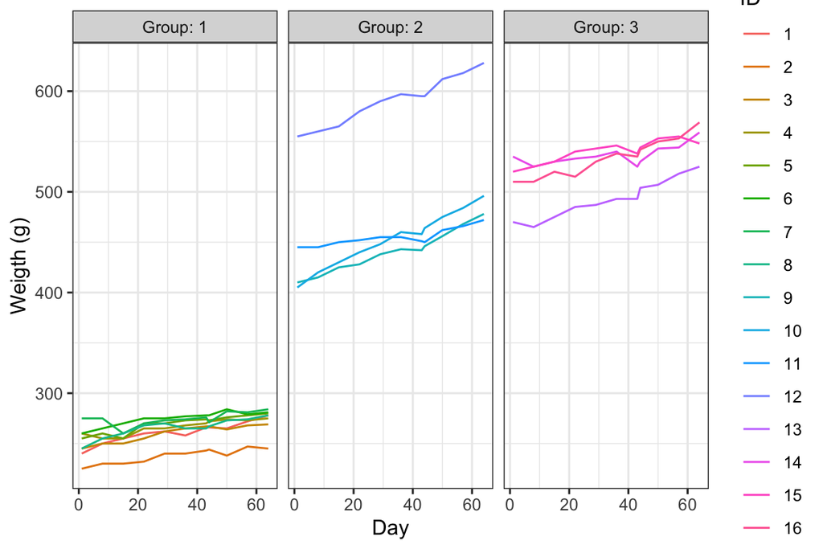

```r
library(ggplot2)

p <- ggplot(RATSL, aes(x = Time, y = Weight)) +
  geom_line(aes(color = ID)) + facet_wrap(~Group, labeller = label_both) +
  ylab("Weigth (g)") + xlab("Day") + theme_bw()

p
```

It seems that the first group had lower rat weights. In the second group there is an outlier weighing over 550 g on the first measurement day, and the third group weighs around 500 g in the beginning of the study. With this graph we can track the weight response of the rats by groups. To focus on the variability, let’s standardize the data and replot.

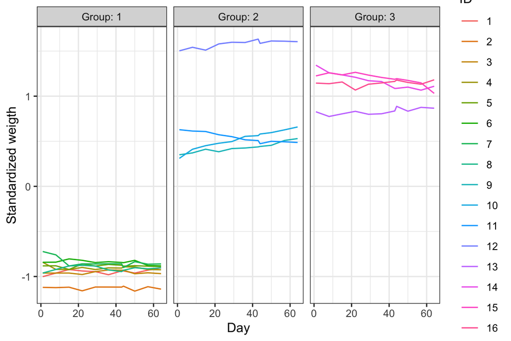

```r
library(tidyverse)

# Standardize weight
RATSL <- RATSL %>%
  group_by(Time) %>%
  mutate(stdweight = (Weight - mean(Weight))/sd(Weight) ) %>%
  ungroup()

p <- ggplot(RATSL, aes(x = Time, y = stdweight)) +
  geom_line(aes(color = ID)) + facet_wrap(~Group, labeller = label_both) +
  ylab("Standardized weigth") + xlab("Day") + theme_bw()

p
```

Now for each measurement day, the weights are standardized around zero to unit variance. It is easier to see the weight differences by ID.

Next, plot mean response profile for the three groups, add standard error.

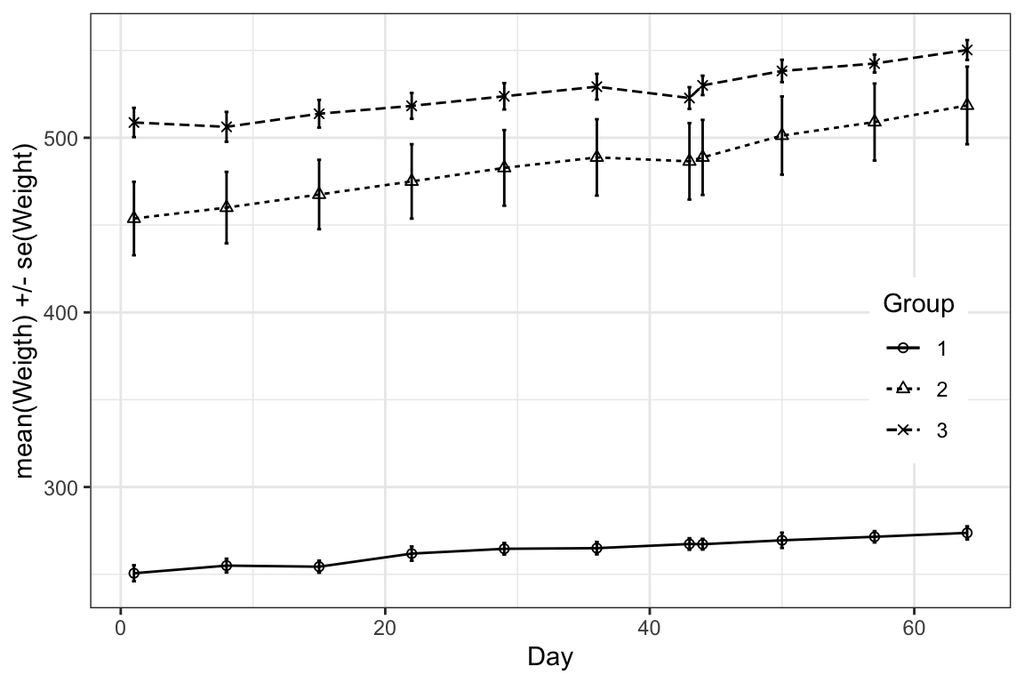

```r
# Count of measurement days
n <- RATSL$Time %>% unique() %>% length()

# Mean and standard error of weight by Group and Time
RATSS <- RATSL %>%
  group_by(Group, Time) %>%
  summarise(mean = mean(Weight), se = sd(Weight) / sqrt(n)) %>%
  ungroup()

# Plot the mean profiles
ggplot(RATSS, aes(x = Time, y = mean, linetype = Group, shape = Group)) +
  geom_line() + geom_point() +
  scale_shape_manual(values = c(1, 2, 4)) + # nicer shapes
  geom_errorbar(aes(ymin = mean - se, ymax = mean + se, linetype="1"), width=0.3) +
  ylab("mean(Weigth) +/- se(Weight)") + xlab("Day") +
  theme_bw() +
  theme(legend.position = c(0.9, 0.4))
```

Group 1 is clearly lighter than others. Groups 2 and 3 are quite close in weight (without overlapping). There is more variation in group 2 due to the outlier.

Alternatively, plot boxplot to display variance between groups by time.

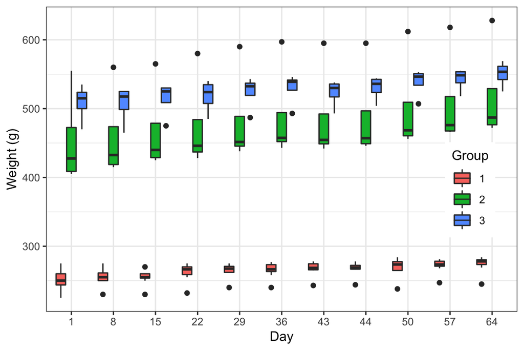

```r
p <- ggplot(RATSL, aes(x = factor(Time), y = Weight, fill = Group)) +
  geom_boxplot() +
  ylab("Weight (g)") + xlab("Day") +
  theme_bw() +
  theme(legend.position = c(0.9, 0.4))

p
```

For this data, the previous plot was clearer as the boxes here are far apart on the y axes and difficult to follow.

### Summary measures

RATS is a growth data. Choose mean as the summary measure and plot (linear regression performed later).

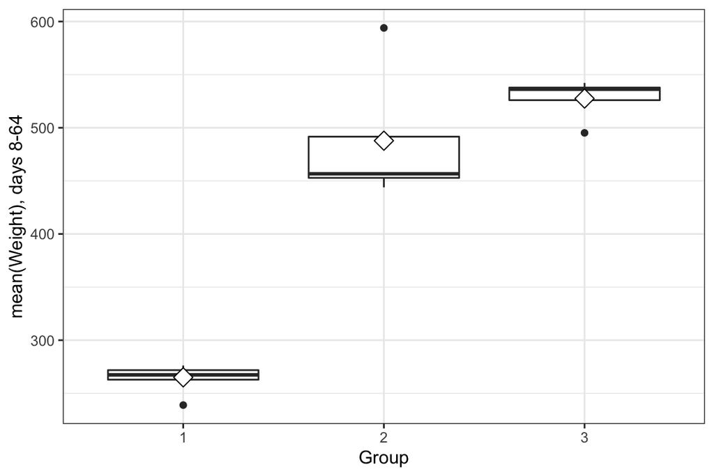

```r
# Filter the first day, group by Group and ID, summarize by group
RATSLD <- RATSL %>%
  filter(Time > 1) %>%
  group_by(Group, ID) %>%
  summarise(mean = mean(Weight)) %>%
  ungroup()

# Boxplot
p <- ggplot(RATSLD, aes(x = Group, y = mean)) +
  geom_boxplot() +
  stat_summary(fun = "mean", geom = "point", shape = 23, size = 4, fill = "white") +
  ylab("mean(Weight), days 8-64") +
  theme_bw()

p
```

Boxplot shows an outlier for each group. Groups 2 and 3 are somewhat skewed. We will not systematically remove outliers based on this plot, because that would amount to almost 20% of data (3 / 16). Outlier from group 2 could however be probably removed, although that too would amount to removing 25% of the group data. Should we want to remove the outlier, the code would be

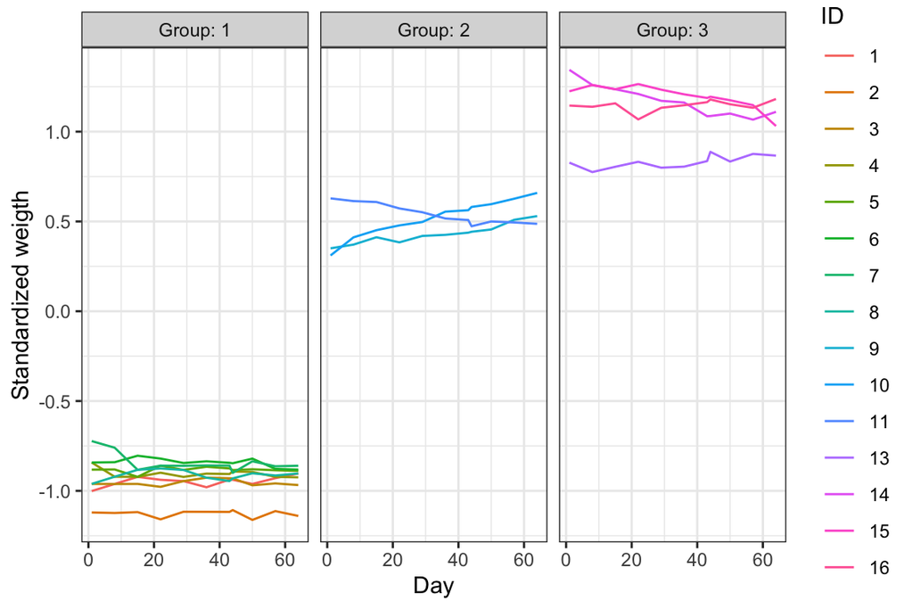

```r
outID <- RATSL %>% filter(Time == 64 & Weight > 600) %>% select(ID)

RATSLout <- RATSL %>%
  filter(ID != outID$ID)

# Verify with a plot
ggplot(RATSLout, aes(x = Time, y = stdweight)) +
  geom_line(aes(color = ID)) + facet_wrap(~Group, labeller = label_both) +
  ylab("Standardized weigth") + xlab("Day") + theme_bw()
```

Work with the full data (no outiliers removed), perform Anova and t-tests to assess if there is difference between group means. (Follow the guide [here](https://www.datanovia.com/en/blog/how-to-perform-t-test-for-multiple-groups-in-r/).)

```r
library(rstatix)

aov.rats <- RATSL %>% anova_test(Weight ~ Group)
aov.rats
```

```
## ANOVA Table (type II tests)
##
##   Effect DFn DFd       F        p p<.05  ges
## 1  Group   2 173 998.175 9.97e-96     * 0.92
```

Clearly, there are differences between groups.

```r
# Perform pairwise t-tests, adjust with Bonferroni
# Assume equal variance, but see
# https://stats.stackexchange.com/questions/305/

pairwise.ts <- RATSL %>%
  pairwise_t_test(Weight ~ Group, p.adjust.method = "bonferroni", detailed = FALSE,
                  pool.sd = FALSE, var.equal = TRUE)  # pool.sd == FALSE -> normal t-tests

pairwise.ts
```

```
## # A tibble: 3 x 10
##   .y.    group1 group2    n1    n2 statistic    df         p     p.adj
## * <chr>  <chr>  <chr>  <int> <int>     <dbl> <dbl>     <dbl>     <dbl>
## 1 Weight 1      2         88    44    -30.5    130 4   e- 61 1.2 e- 60
## 2 Weight 1      3         88    44    -79.0    130 9.6 e-112 2.88e-111
## 3 Weight 2      3         44    44     -3.91    86 1.86e-  4 5.58e-  4
## # … with 1 more variable: p.adj.signif <chr>
```

All group differences appear significant. Add box plot on full (not mean) data with the signficance annotation.

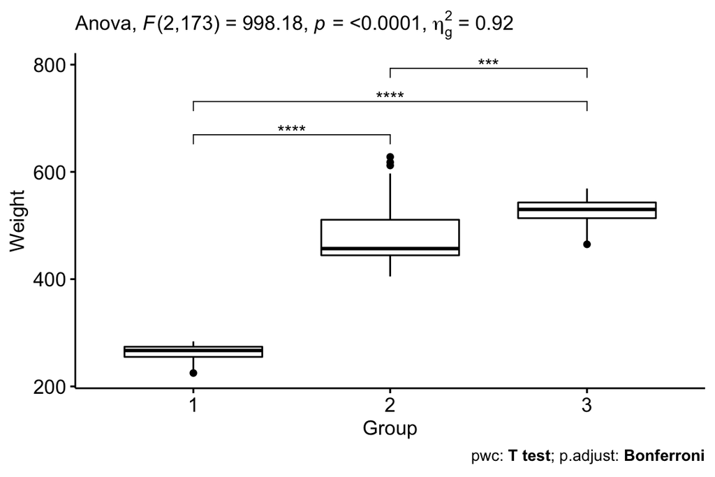

```r
library(ggpubr)

# Add positions for significance indincators
pairwise.ts <- pairwise.ts %>% add_xy_position(x = "Group")

ggboxplot(RATSL, x = "Group", y = "Weight") +
  stat_pvalue_manual(pairwise.ts, hide.ns = TRUE, label = "p.adj.signif") +
  labs(
    subtitle = get_test_label(aov.rats, detailed = TRUE),
    caption = get_pwc_label(pairwise.ts)
    )
```

Eta squared is high, 92% of variance in weight is explained by group.

Also perform the pairwise t-test on group means

```r
RATSLD %>%
  pairwise_t_test(mean ~ Group, p.adjust.method = "bonferroni", pool.sd = FALSE, var.equal = TRUE)
```

```
## # A tibble: 3 x 10
##   .y.   group1 group2    n1    n2 statistic    df        p    p.adj p.adj.signif
## * <chr> <chr>  <chr>  <int> <int>     <dbl> <dbl>    <dbl>    <dbl> <chr>
## 1 mean  1      2          8     4     -9.06    10 3.88e- 6 1.16e- 5 ****
## 2 mean  1      3          8     4    -27.8     10 8.34e-11 2.5 e-10 ****
## 3 mean  2      3          4     4     -1.07     6 3.26e- 1 9.78e- 1 ns
```

The difference in mean is not significant between groups 2 and 3.

Finally, incorporate the first day as baseline to use in the covariate analysis.

```r
RATSW <- RATSL %>%
  select(-stdweight) %>%
  pivot_wider(names_from = Time, values_from = Weight, names_prefix = "week")

RATSLD <- RATSLD %>%
  mutate(baseline = RATSW$`week1`)

# Fit the linear model with the mean as the response
RATSW_lm <- lm(mean ~ baseline + Group, data = RATSLD)

# Compute the analysis of variance table for the fitted model
anova(RATSW_lm)
```

```
## Analysis of Variance Table
##
## Response: mean
##           Df Sum Sq Mean Sq   F value   Pr(>F)
## baseline   1 253625  253625 1859.8201 1.57e-14 ***
## Group      2    879     439    3.2219  0.07586 .
## Residuals 12   1636     136
## ---
## Signif. codes:  0 '***' 0.001 '**' 0.01 '*' 0.05 '.' 0.1 ' ' 1
```

Baseline measurement is strongly significant having an effect on the weight mean. There doesn’t seem to be significant difference by groups. From the diagnostic plots below, we see however that there might be a heteroscedasticity as well as outlier problems (by Cook’s distance).

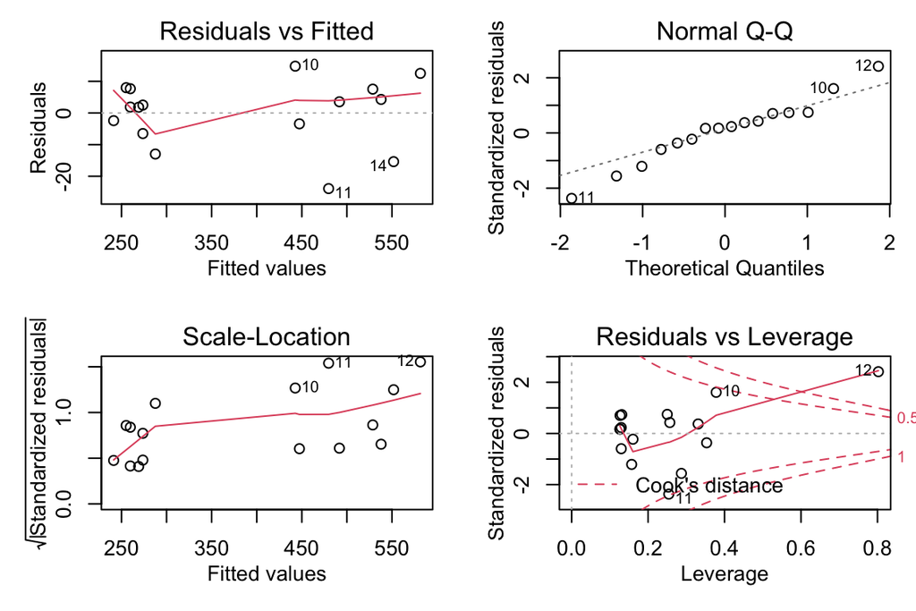

```r
# make the plot tighter
op <- par(mfrow=c(2, 2),
          mar = c(4, 4, 2, 1),
          mgp = c(2, 1, 0))

plot(RATSW_lm)

par(op)
```

Check also the simple linear regression to compare the groups without the baseline

```r
RATS_lm <- lm(Weight ~ Group, data = RATSL)
summary(RATS_lm)
```

```
##
## Call:
## lm(formula = Weight ~ Group, data = RATSL)
##
## Residuals:
##     Min      1Q  Median      3Q     Max
## -79.705 -19.026   1.284  11.287 143.295
##
## Coefficients:
##             Estimate Std. Error t value Pr(>|t|)
## (Intercept)  263.716      3.850   68.50   <2e-16 ***
## Group2       220.989      6.668   33.14   <2e-16 ***
## Group3       262.080      6.668   39.30   <2e-16 ***
## ---
## Signif. codes:  0 '***' 0.001 '**' 0.01 '*' 0.05 '.' 0.1 ' ' 1
##
## Residual standard error: 36.12 on 173 degrees of freedom
## Multiple R-squared:  0.9203, Adjusted R-squared:  0.9193
## F-statistic: 998.2 on 2 and 173 DF,  p-value: < 2.2e-16
```

There are differences between the groups relative to group 1, but the linear model is again not terribly good:

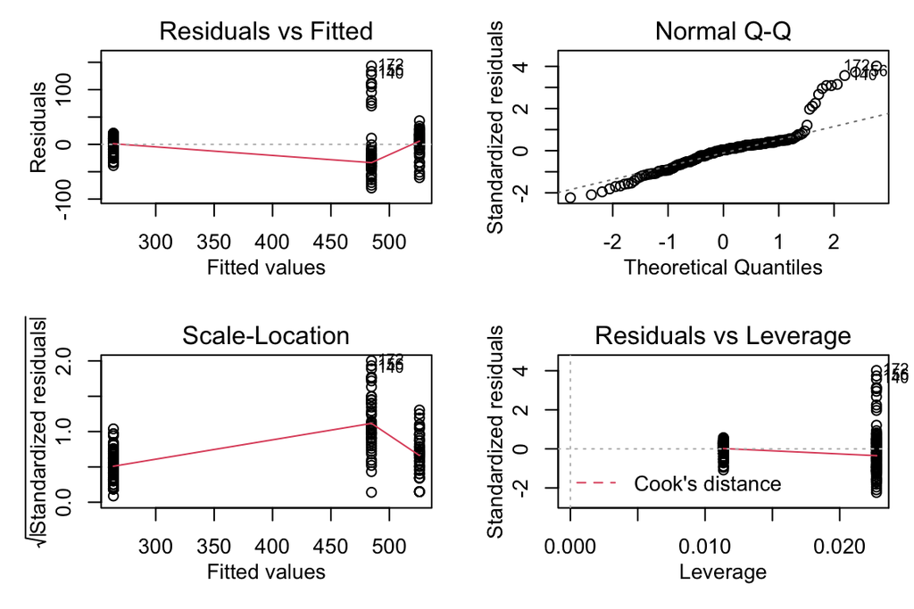

```r
# make the plot tighter
op <- par(mfrow=c(2, 2),
          mar = c(4, 4, 2, 1),
          mgp = c(2, 1, 0))

plot(RATS_lm)

par(op)
```

## BPRS

Begin by loading the analysis data in long form.

```r
# read in the data, convert strings to factors
BPRSL <- read.csv("./data/bprsl.csv", header = TRUE, sep = ",", row.names = 1)

dim(BPRSL)
```

```
## [1] 360   4
```

```r
str(BPRSL)
```

```
## 'data.frame':    360 obs. of  4 variables:
##  $ treatment: int  1 1 1 1 1 1 1 1 1 1 ...
##  $ subject  : int  1 2 3 4 5 6 7 8 9 10 ...
##  $ week     : int  0 0 0 0 0 0 0 0 0 0 ...
##  $ bprs     : int  42 58 54 55 72 48 71 30 41 57 ...
```

```r
# convert to factor
BPRSL$subject <- as.factor(BPRSL$subject)
BPRSL$treatment <- as.factor(BPRSL$treatment)
```

```r
summary(BPRSL)
```

```
##  treatment    subject         week        bprs
##  1:180     1      : 18   Min.   :0   Min.   :18.00
##  2:180     2      : 18   1st Qu.:2   1st Qu.:27.00
##            3      : 18   Median :4   Median :35.00
##            4      : 18   Mean   :4   Mean   :37.66
##            5      : 18   3rd Qu.:6   3rd Qu.:43.00
##            6      : 18   Max.   :8   Max.   :95.00
##            (Other):252
```

```r
unique(BPRSL$subject)
```

```
##  [1] 1  2  3  4  5  6  7  8  9  10 11 12 13 14 15 16 17 18 19 20
## Levels: 1 2 3 4 5 6 7 8 9 10 11 12 13 14 15 16 17 18 19 20
```

`bprs` values span from 18 to 95, there are 9 measurement weeks, 2 treatments and 20 subjects.

### BPRS profiles

Plot the profiles with text labels by treatment.

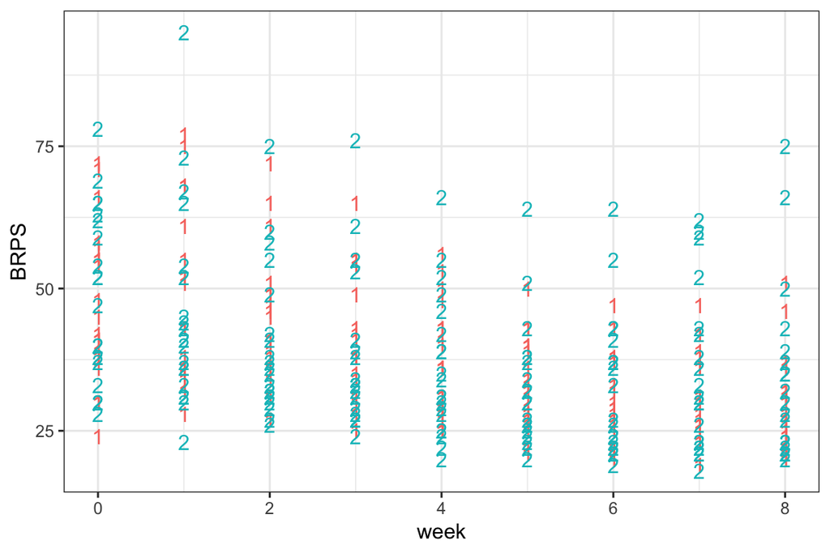

```r
p <- ggplot(BPRSL, aes(x = week, y = bprs, group = subject)) +
  geom_text(aes(label = treatment, color = treatment)) +
  xlab("week") +
  ylab("BRPS") +
  theme_bw() +
  theme(legend.position = "none")

p
```

The plot is messy as the treatments overlap, even with colors. Plot with lines instead, and panel by treatment to increase clarity.

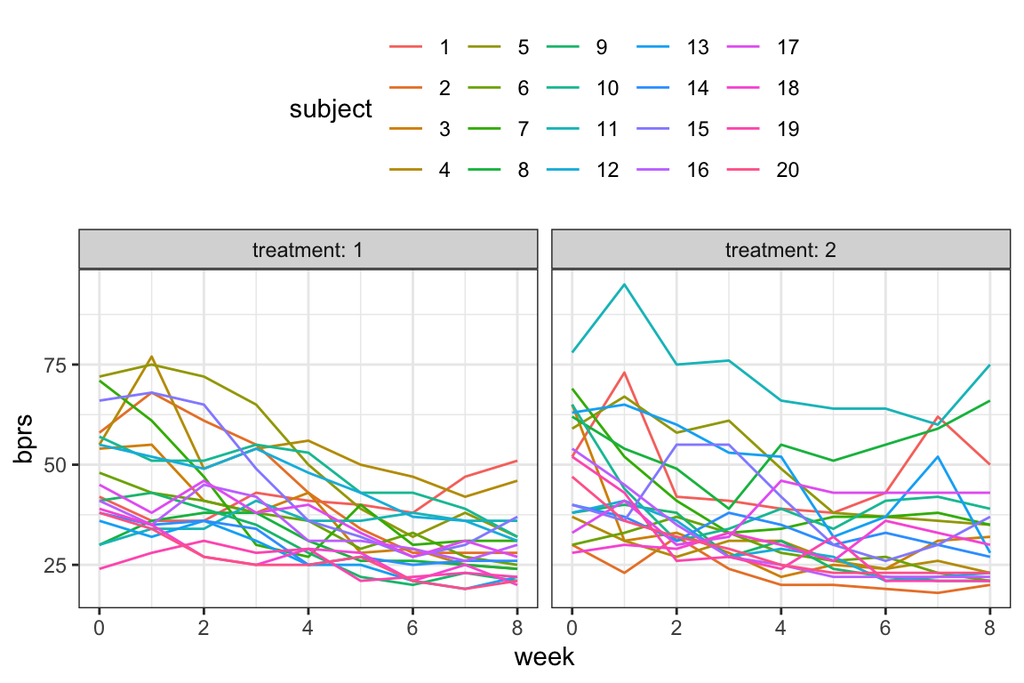

```r
p <- ggplot(BPRSL, aes(x = week, y = bprs, color = subject)) +
  geom_line() +
  theme_bw() +
  theme(legend.position = "top") +
  facet_wrap(~treatment, labeller = label_both)

p
```

The plot is not terribly good either, it is hard to track the subjects and even harder to see the difference by treatment on a subject level. In treatment 2, there is an outlier, but we keep the subject is not an outlier in the other treatment group.

Let’s plot a mean aggregate profile, and then fit some models to learn more about the data.

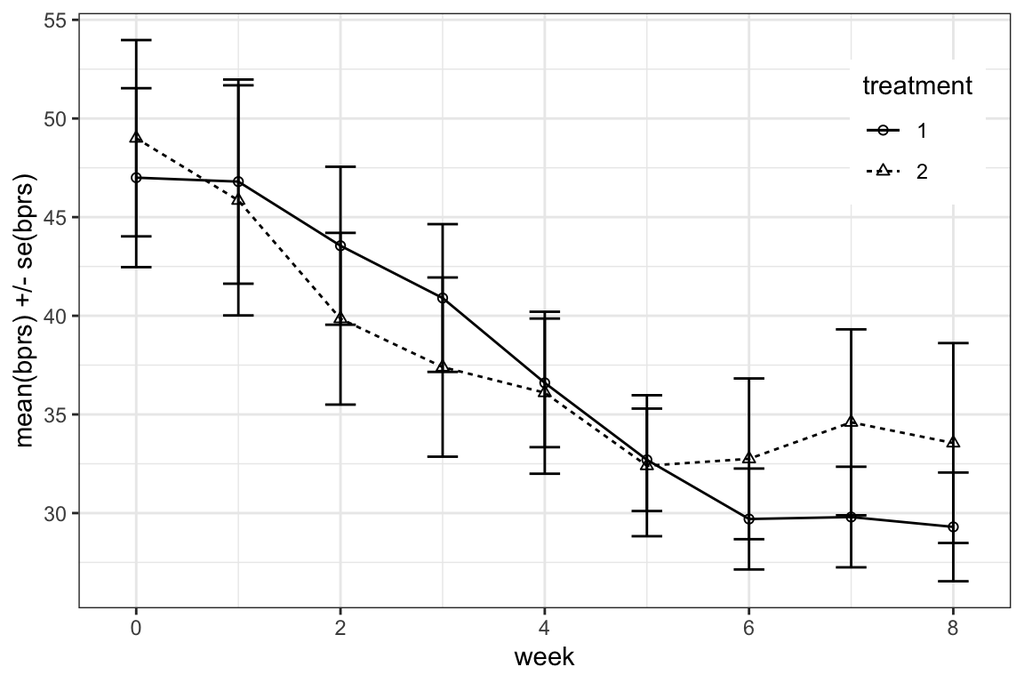

```r
# Count of measurement days
n <- BPRSL$week %>% unique() %>% length()

# Mean and standard error of weight by Group and time
BPRSS <- BPRSL %>%
  group_by(treatment, week) %>%
  summarise(mean = mean(bprs), se = sd(bprs) / sqrt(n)) %>%
  ungroup()

# Plot the mean profiles
ggplot(BPRSS, aes(x = week, y = mean, linetype = treatment, shape = treatment)) +
  geom_line() + geom_point() +
  scale_shape_manual(values = c(1, 2, 4)) + # nicer shapes
  geom_errorbar(aes(ymin = mean - se, ymax = mean + se, linetype="1"), width=0.3) +
  ylab("mean(bprs) +/- se(bprs)") + xlab("week") +
  theme_bw() +
  theme(legend.position = c(0.9, 0.8))
```

As suspected, there does not seem to be a big difference by treatment on any particular week.

Finally, plot a box plot for treatment and subject grouping and ignore the baseline

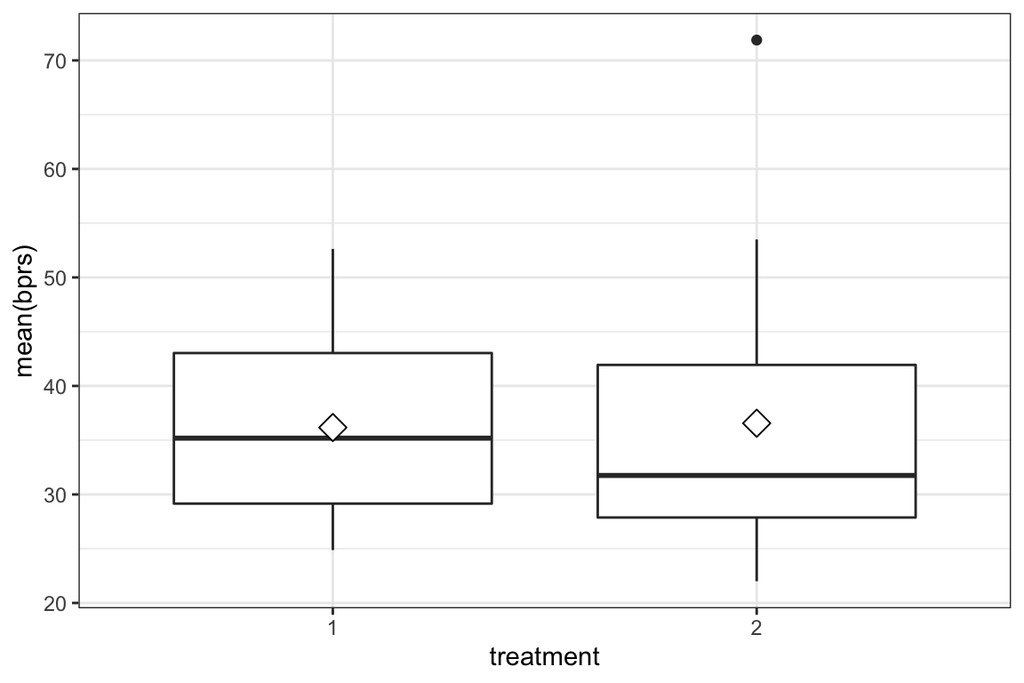

```r
# from Datacamp exercise
BPRSL8S <- BPRSL %>%
  filter(week > 0) %>%
  group_by(treatment, subject) %>%
  summarise(mean = mean(bprs)) %>%
  ungroup()

ggplot(BPRSL8S, aes(x = treatment, y = mean)) +
  geom_boxplot() +
  stat_summary(fun = "mean", geom = "point", shape = 23, size = 4, fill = "white") +
  ylab("mean(bprs)") +
  theme_bw()
```

There is an outlier in the treatment group 2 as seen before in the line plot.

### Simple linear regression

Fit a linear regression model

```r
BPRS_reg <- lm(bprs ~ week + treatment, data = BPRSL)

summary(BPRS_reg)
```

```
##
## Call:
## lm(formula = bprs ~ week + treatment, data = BPRSL)
##
## Residuals:
##     Min      1Q  Median      3Q     Max
## -22.454  -8.965  -3.196   7.002  50.244
##
## Coefficients:
##             Estimate Std. Error t value Pr(>|t|)
## (Intercept)  46.4539     1.3670  33.982   <2e-16 ***
## week         -2.2704     0.2524  -8.995   <2e-16 ***
## treatment2    0.5722     1.3034   0.439    0.661
## ---
## Signif. codes:  0 '***' 0.001 '**' 0.01 '*' 0.05 '.' 0.1 ' ' 1
##
## Residual standard error: 12.37 on 357 degrees of freedom
## Multiple R-squared:  0.1851, Adjusted R-squared:  0.1806
## F-statistic: 40.55 on 2 and 357 DF,  p-value: < 2.2e-16
```

Plot a quick overview of the residuals to see if a linear regression is appropriate.

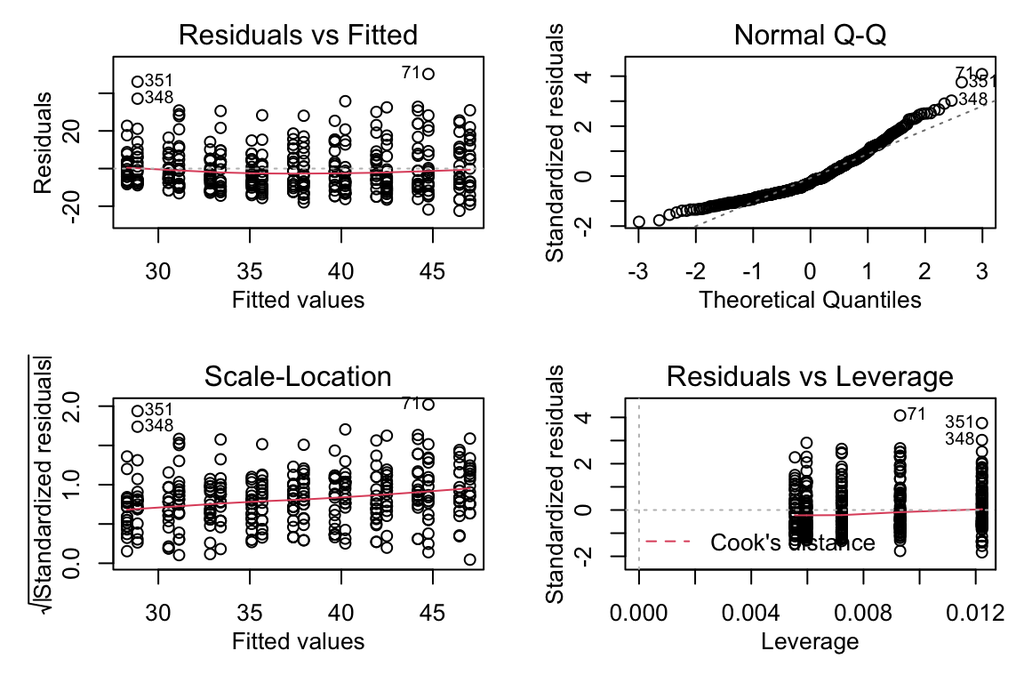

```r
# make the plot tighter
op <- par(mfrow=c(2, 2),
          mar = c(4, 4, 2, 1),
          mgp = c(2, 1, 0))

plot(BPRS_reg)

par(op) # return original par
```

Linear fit seems OK.

Week is significant, as well as the non-zero intercept. However, treatment conditional on week seems to not be significant. Maybe our model is not good enough to capture the treatment difference.

Plot scatterplot matrix of repeated measures to assess if there is a pattern between weeks.

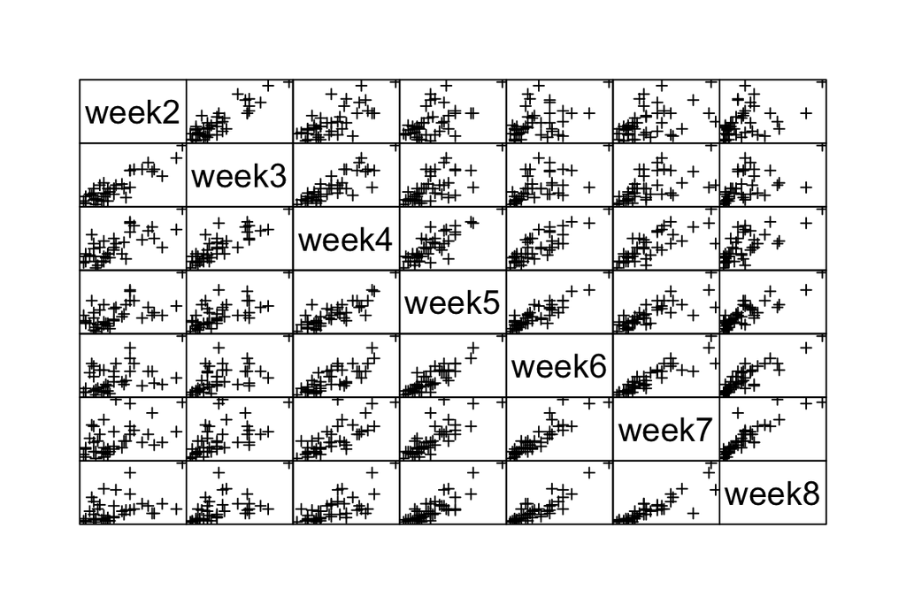

```r
# to wide
BPRSW <- BPRSL %>%
  pivot_wider(names_from = week, values_from = bprs, names_prefix = "week") %>%
  select(-c(treatment, subject))

pairs(BPRSW[, 3:ncol(BPRSW)],
      gap = 0, xaxt = "n", yaxt = "n", pch = 3)
```

There appears to be autocorrelation, which reduces as the weeks get further apart. It makes sense to capture the autocorrelation with better models that take into account the repeated measures nature of the data. To that end, fit linear mixed models.

Before the models, plot correlations to get numerical values

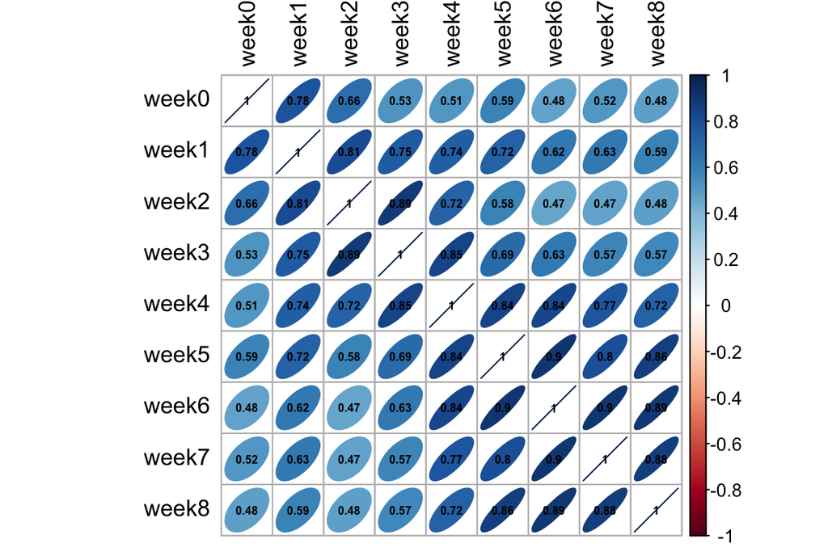

```r
library(corrplot)

cor.matrix <- cor(BPRSW)

rownames(cor.matrix) <- colnames(cor.matrix)

corrplot(as.matrix(cor.matrix), method = "ellipse",
         order = "original", number.cex = 0.5,  # Use some nice ordering
         tl.cex = 1, tl.col = "black", addCoef.col = 'black')
```

### Linear mixed models

#### Random intercept

First create a random intercept model.

```r
library(lme4)

# optimize log-likelihood
BPRS_ref <- lmer(bprs ~ week + treatment + (1 | subject), data = BPRSL, REML = FALSE)
summary(BPRS_ref)
```

```
## Linear mixed model fit by maximum likelihood  ['lmerMod']
## Formula: bprs ~ week + treatment + (1 | subject)
##    Data: BPRSL
##
##      AIC      BIC   logLik deviance df.resid
##   2748.7   2768.1  -1369.4   2738.7      355
##
## Scaled residuals:
##     Min      1Q  Median      3Q     Max
## -3.0481 -0.6749 -0.1361  0.4813  3.4855
##
## Random effects:
##  Groups   Name        Variance Std.Dev.
##  subject  (Intercept)  47.41    6.885
##  Residual             104.21   10.208
## Number of obs: 360, groups:  subject, 20
##
## Fixed effects:
##             Estimate Std. Error t value
## (Intercept)  46.4539     1.9090  24.334
## week         -2.2704     0.2084 -10.896
## treatment2    0.5722     1.0761   0.532
##
## Correlation of Fixed Effects:
##            (Intr) week
## week       -0.437
## treatment2 -0.282  0.000
```

The random effect variances for the `subject` and residuals appear reasonable: Subject random effects variance is not too large. Residual variance is smaller than in the simple baseline model.

Regression parameters for week and treatment appear identical to the baseline. The standard errors for both `week` and `treatment2` are a bit smaller, likely reflecting incorporation of the within-subject dependence (unlike in the textbook example, here the treatment variable does not have a larger variance compared to the baseline model; this is perhaps due to larger group sizes than in the RATS data).

There is some negative correlation of the regression coefficients with the intercept (see [here](https://stats.stackexchange.com/questions/57240/)).

Compare to the baseline model using AIC:

```r
# https://stackoverflow.com/questions/24019807/

AIC(BPRS_reg, BPRS_ref)
```

```
##          df      AIC
## BPRS_reg  4 2837.337
## BPRS_ref  5 2748.712
```

The mixed effects model is better. It would be informative to get the p-values as well:

```r
# With the caveats in
# https://stats.stackexchange.com/questions/22988/

library(lmerTest)
fit <- lmerTest::lmer(bprs ~ week + treatment + (1 | subject), data = BPRSL, REML = FALSE)
summary(fit)
```

```
## Linear mixed model fit by maximum likelihood . t-tests use Satterthwaite's
##   method [lmerModLmerTest]
## Formula: bprs ~ week + treatment + (1 | subject)
##    Data: BPRSL
##
##      AIC      BIC   logLik deviance df.resid
##   2748.7   2768.1  -1369.4   2738.7      355
##
## Scaled residuals:
##     Min      1Q  Median      3Q     Max
## -3.0481 -0.6749 -0.1361  0.4813  3.4855
##
## Random effects:
##  Groups   Name        Variance Std.Dev.
##  subject  (Intercept)  47.41    6.885
##  Residual             104.21   10.208
## Number of obs: 360, groups:  subject, 20
##
## Fixed effects:
##             Estimate Std. Error       df t value Pr(>|t|)
## (Intercept)  46.4539     1.9090  37.2392  24.334   <2e-16 ***
## week         -2.2704     0.2084 340.0000 -10.896   <2e-16 ***
## treatment2    0.5722     1.0761 340.0000   0.532    0.595
## ---
## Signif. codes:  0 '***' 0.001 '**' 0.01 '*' 0.05 '.' 0.1 ' ' 1
##
## Correlation of Fixed Effects:
##            (Intr) week
## week       -0.437
## treatment2 -0.282  0.000
```

```r
# or with anova
anova(fit)
```

```
## Type III Analysis of Variance Table with Satterthwaite's method
##            Sum Sq Mean Sq NumDF DenDF  F value Pr(>F)
## week      12371.5 12371.5     1   340 118.7136 <2e-16 ***
## treatment    29.5    29.5     1   340   0.2828 0.5952
## ---
## Signif. codes:  0 '***' 0.001 '**' 0.01 '*' 0.05 '.' 0.1 ' ' 1
```

Well, there is more output but the conclusion is the same. `week` has a significant effect on `bprs` while treatment group does not. Let’s use `lmerTest::lmer` from now on to print the p-values as well.

Next add variable slope.

#### Random intercept and slope model

```r
BPRS_ref1 <- lmerTest::lmer(bprs ~ week + treatment + (week | subject), data = BPRSL, REML = FALSE)
summary(BPRS_ref1)
```

```
## Linear mixed model fit by maximum likelihood . t-tests use Satterthwaite's
##   method [lmerModLmerTest]
## Formula: bprs ~ week + treatment + (week | subject)
##    Data: BPRSL
##
##      AIC      BIC   logLik deviance df.resid
##   2745.4   2772.6  -1365.7   2731.4      353
##
## Scaled residuals:
##     Min      1Q  Median      3Q     Max
## -2.8919 -0.6194 -0.0691  0.5531  3.7976
##
## Random effects:
##  Groups   Name        Variance Std.Dev. Corr
##  subject  (Intercept) 64.8222  8.0512
##           week         0.9609  0.9802   -0.51
##  Residual             97.4305  9.8707
## Number of obs: 360, groups:  subject, 20
##
## Fixed effects:
##             Estimate Std. Error       df t value Pr(>|t|)
## (Intercept)  46.4539     2.1052  22.6795  22.066  < 2e-16 ***
## week         -2.2704     0.2977  19.9991  -7.626 2.42e-07 ***
## treatment2    0.5722     1.0405 320.0005   0.550    0.583
## ---
## Signif. codes:  0 '***' 0.001 '**' 0.01 '*' 0.05 '.' 0.1 ' ' 1
##
## Correlation of Fixed Effects:
##            (Intr) week
## week       -0.582
## treatment2 -0.247  0.000
```

We reach the same conclusions as with the random intercept model. Residual variance is lower, but the subject variance increased. Now we also have data on the variance for `week` random effect and there is negative correlation for the variance of intercept and slope (see [here](https://stats.stackexchange.com/questions/24452/)).

```r
AIC(BPRS_ref, BPRS_ref1)
```

```
##           df      AIC
## BPRS_ref   5 2748.712
## BPRS_ref1  7 2745.440
```

```r
anova(BPRS_ref, BPRS_ref1)
```

```
## Data: BPRSL
## Models:
## BPRS_ref: bprs ~ week + treatment + (1 | subject)
## BPRS_ref1: bprs ~ week + treatment + (week | subject)
##           npar    AIC    BIC  logLik deviance  Chisq Df Pr(>Chisq)
## BPRS_ref     5 2748.7 2768.1 -1369.4   2738.7
## BPRS_ref1    7 2745.4 2772.6 -1365.7   2731.4 7.2721  2    0.02636 *
## ---
## Signif. codes:  0 '***' 0.001 '**' 0.01 '*' 0.05 '.' 0.1 ' ' 1
```

```r
# or
# library(lmtest)
# lrtest(BPRS_ref, BPRS_ref1)
```

The likelihood ratio test and AIC suggest that the random intercept and slope model is better.

#### Random intercept and slope model with interaction term

Lastly, add an interaction term between week and treatment.

```r
BPRS_ref2 <- lmerTest::lmer(bprs ~ week * treatment + (week | subject), data = BPRSL, REML = FALSE)
summary(BPRS_ref2)
```

```
## Linear mixed model fit by maximum likelihood . t-tests use Satterthwaite's
##   method [lmerModLmerTest]
## Formula: bprs ~ week * treatment + (week | subject)
##    Data: BPRSL
##
##      AIC      BIC   logLik deviance df.resid
##   2744.3   2775.4  -1364.1   2728.3      352
##
## Scaled residuals:
##     Min      1Q  Median      3Q     Max
## -3.0512 -0.6271 -0.0768  0.5288  3.9260
##
## Random effects:
##  Groups   Name        Variance Std.Dev. Corr
##  subject  (Intercept) 64.9964  8.0620
##           week         0.9687  0.9842   -0.51
##  Residual             96.4707  9.8220
## Number of obs: 360, groups:  subject, 20
##
## Fixed effects:
##                 Estimate Std. Error       df t value Pr(>|t|)
## (Intercept)      47.8856     2.2521  29.6312  21.262  < 2e-16 ***
## week             -2.6283     0.3589  41.7201  -7.323 5.24e-09 ***
## treatment2       -2.2911     1.9090 319.9977  -1.200   0.2310
## week:treatment2   0.7158     0.4010 319.9977   1.785   0.0752 .
## ---
## Signif. codes:  0 '***' 0.001 '**' 0.01 '*' 0.05 '.' 0.1 ' ' 1
##
## Correlation of Fixed Effects:
##             (Intr) week   trtmn2
## week        -0.650
## treatment2  -0.424  0.469
## wek:trtmnt2  0.356 -0.559 -0.840
```

```r
# confint(BPRS_ref2, 'week:treatment2', level=0.95)
```

Interestingly, `week` and `treatment` group has a weakly significant interaction, suggesting that the bprs slope is higher in the treatment group 2 on average by 0.72. On closer inspection, the 95% CI [-0.07, 1.50] contains zero and the effect is lost.

```r
AIC(BPRS_ref1, BPRS_ref2)
```

```
##           df      AIC
## BPRS_ref1  7 2745.440
## BPRS_ref2  8 2744.269
```

```r
anova(BPRS_ref1, BPRS_ref2)
```

```
## Data: BPRSL
## Models:
## BPRS_ref1: bprs ~ week + treatment + (week | subject)
## BPRS_ref2: bprs ~ week * treatment + (week | subject)
##           npar    AIC    BIC  logLik deviance  Chisq Df Pr(>Chisq)
## BPRS_ref1    7 2745.4 2772.6 -1365.7   2731.4
## BPRS_ref2    8 2744.3 2775.4 -1364.1   2728.3 3.1712  1    0.07495 .
## ---
## Signif. codes:  0 '***' 0.001 '**' 0.01 '*' 0.05 '.' 0.1 ' ' 1
```

The more complicated interaction model does not fit the data significantly better by likelihood ratio test (unless divided by 2 as in the textbook, page 179), nor is the AIC too different.

Plot the fitted values. We see that indeed both the slope and the intercepts vary.

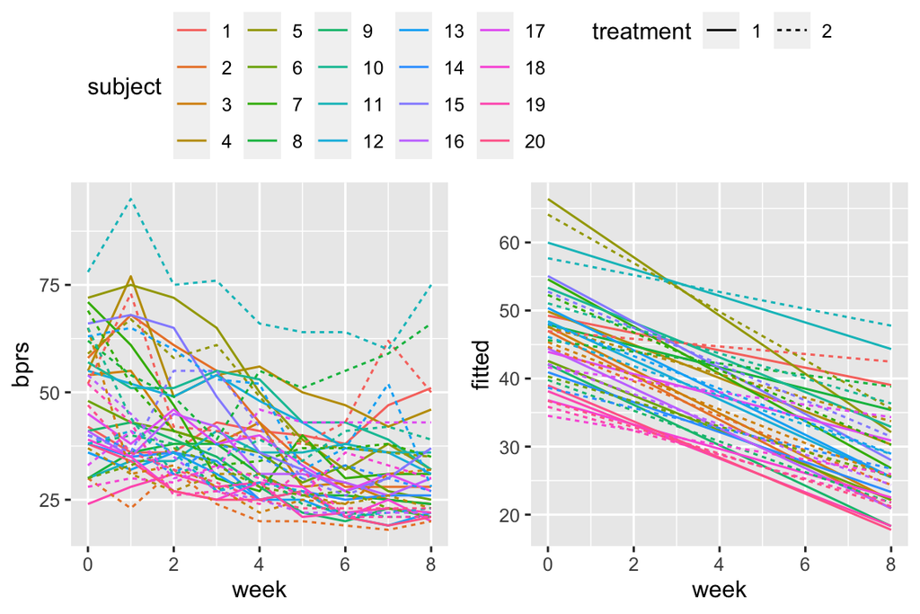

```r
library(ggpubr)

# Create a new column fitted to RATSL
BPRSLF <- BPRSL %>%
  mutate(fitted = fitted(BPRS_ref2))

# BRPSL data
g1 <- ggplot(BPRSLF, aes(x = week, y = bprs, color = subject)) +
  geom_line(aes(linetype = treatment)) +
  theme(legend.position = "top")

# Fitted values with a mixed effects model
g2 <- ggplot(BPRSLF, aes(x = week, y = fitted, color = subject)) +
  geom_line(aes(linetype = treatment)) +
  theme(legend.position = "top")

ggarrange(g1, g2,
          ncol = 2, nrow = 1, common.legend = TRUE,
          legend = "top")
```

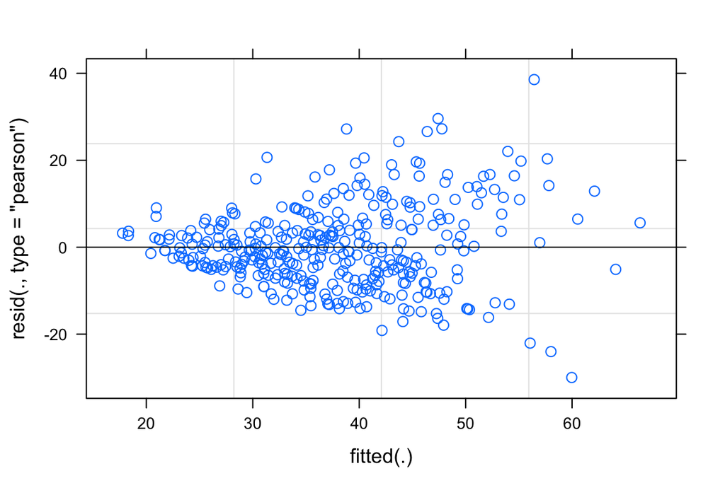

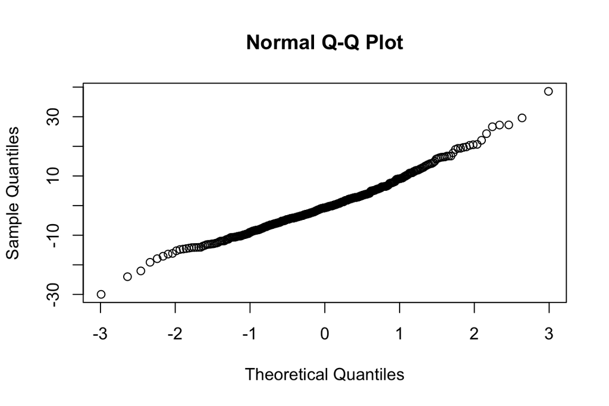

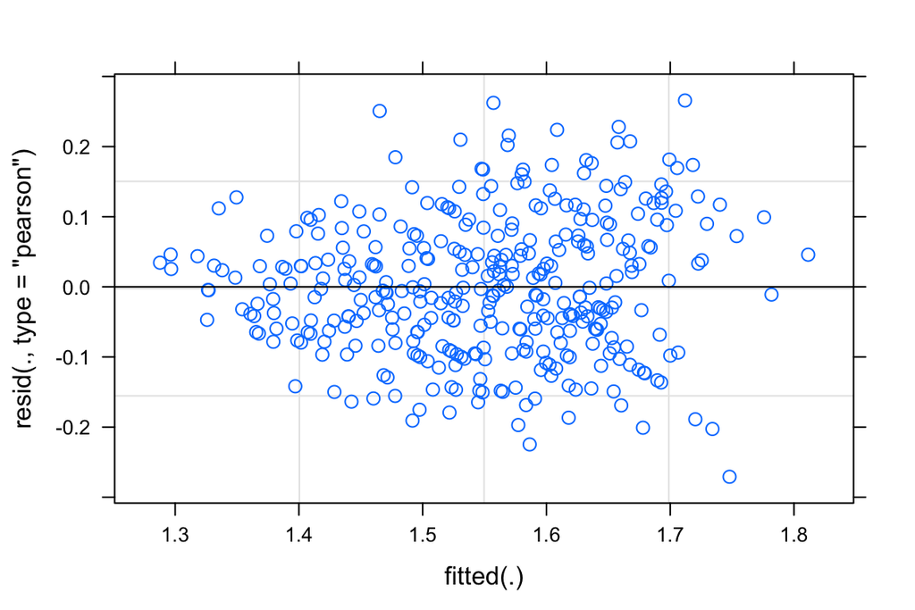

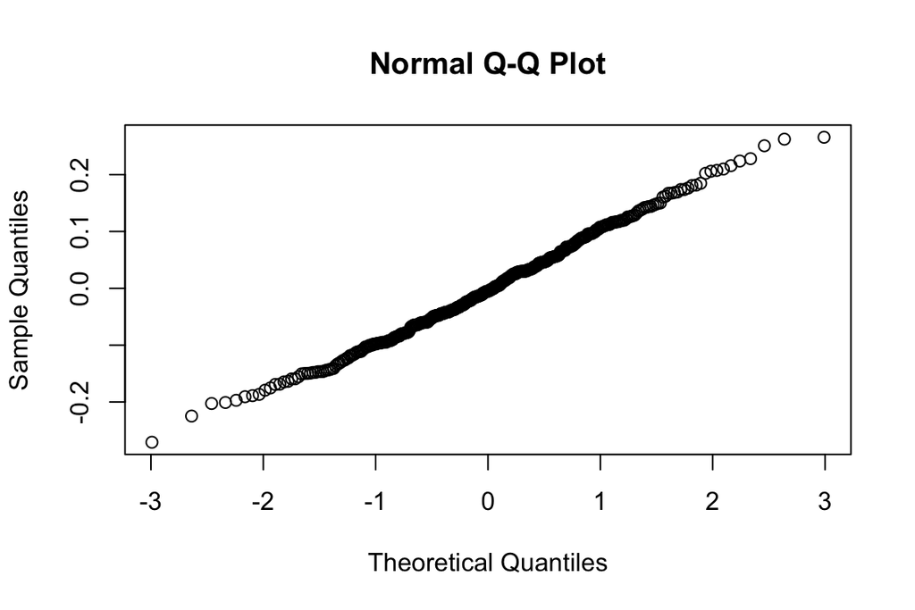

```r
plot(BPRS_ref2)
qqnorm(resid(BPRS_ref2))

# transform
BPRSLOG <- BPRSL
BPRSLOG$bprs <- log10(BPRSLOG$bprs)
BPRS_ref3 <- lmerTest::lmer(bprs ~ week * treatment + (week | subject), data = BPRSLOG, REML = FALSE)
plot(BPRS_ref3)
qqnorm(resid(BPRS_ref3))
```

(Course chapters completed.)